# 72 Calculus plots with Makie

The [Makie.jl webpage](https://github.com/JuliaPlots/Makie.jl) says

> From the Japanese word Maki-e, which is a technique to sprinkle lacquer with gold and silver powder. Data is basically the gold and silver of our age, so let’s spread it out beautifully on the screen!

`Makie` itself is a metapackage for a rich ecosystem. We show how to use the interface provided by the `CairoMakie` backend to produce the familiar graphics of calculus.

**NoteExamples and tutorials**

`Makie` is a sophisticated plotting package, and capable of an enormous range of plots (cf. [examples](https://makie.juliaplots.org/stable/examples/plotting_functions/).) `Makie` also has numerous [tutorials](https://makie.juliaplots.org/stable/tutorials/) to learn from. These are far more extensive than what is described herein, as this section focuses just on the graphics from calculus.

## 72.1 Figures

Makie draws graphics onto a canvas termed a “scene” in the Makie documentation. A scene is an implementation detail, the basic (non-mutating) plotting commands described below return a `FigureAxisPlot` object, a compound object that combines a figure, an axes, and a plot object. We also briefly show the details of constructing a separate figure and axis. The `show` method for figures displays the resulting graphic.

For `Makie` there are the different backends for different types of canvases. In the following, we have used `CairoMakie`.

We begin by loading the main package and the `norm` function from the standard `LinearAlgebra` package:

```julia
using CairoMakie
import LinearAlgebra: norm
```

The package load time as of recent version of `Makie` is quite reasonable for a complicated project. (The time to first plot is around five seconds on a typical machine.)

## 72.2 Points (`scatter`)

The task of plotting the points, say $(1,2)$, $(2,3)$, $(3,2)$ can be done different ways.

- We can plot two vectors holding the `x` and `y` coordinates, e.g. `[1,2,3]` and `[2,3,2]`.
- Using a tuple to represent a point, we can plot a vector of tuples, e.g. `[(1,2), (2,3), (3,2)]`.
- More idiomatically, using a `Point2` object to represent a point, a vector of point objects can be plotted, e.g. `[Point2(1,2), Point2(2,3), Point2(3,2)]`.

The `Point2` function also accepts a vector or tuple for input to describe the point. There is also `Point3` for 3-d plotting. `Makie` uses a GPU, when present, to accelerate the graphic rendering. GPUs employ 32-bit numbers. Julia uses an `f0` to indicate 32-bit floating points. Hence the alternate types `Point2f0` to store 2D points as 32-bit numbers and `Points3f0` to store 3D points as 32-bit numbers are seen in the documentation for Makie.

It is not so difficult to convert between these storage formats. For example starting with

```julia
xs = [1, 2, 3]
ys = [2, 3, 2]
```

```
3-element Vector{Int64}:
 2
 3
 2
```

We can convert to a vector of tuples using broadcasting or `zip`:

```julia
tuple.(xs, ys), collect(zip(xs, ys))
```

```
([(1, 2), (2, 3), (3, 2)], [(1, 2), (2, 3), (3, 2)])
```

A vector of points can be generated similarly:

```julia
Point2.(xs, ys), Point2.(zip(xs, ys))
```

```
(Point{2, Int64}[[1, 2], [2, 3], [3, 2]], Point{2, Int64}[[1, 2], [2, 3], [3, 2]])
```

The `unzip` function from the `CalculusWithJulia` package can reverse this direction:

```julia
using CalculusWithJulia: unzip # just SplitApplyCombine.invert
unzip(Point2.(xs, ys))
```

```
([1, 2, 3], [2, 3, 2])
```

We illustrate in Figure 72.1 where we generate a vector of points using these two functions:

```julia
r(t) = [cos(t), sin(t)]
h(t) = (cos(t), sin(t), t)
ts = range(0, 2pi, 25)
```

```
0.0:0.2617993877991494:6.283185307179586
```

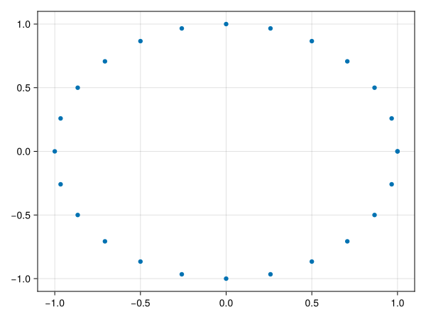

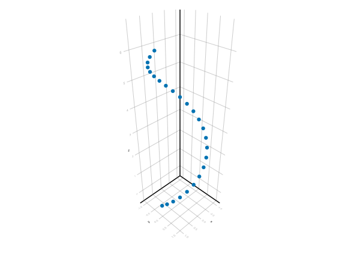

Figure 72.1: A scatter plot in 2d and 3d generated by broadscasting `Point2` over a vector of 2 component vectors and `Point3` over a vector of 3 component tuples.

```julia
scatter(Point2.(r.(ts)))
scatter(Point3.(h.(ts)))
```

### 72.2.1 Attributes of a marker

A point is drawn with a “marker” with a certain size and color. These attributes can be adjusted, as in Figure 72.2.

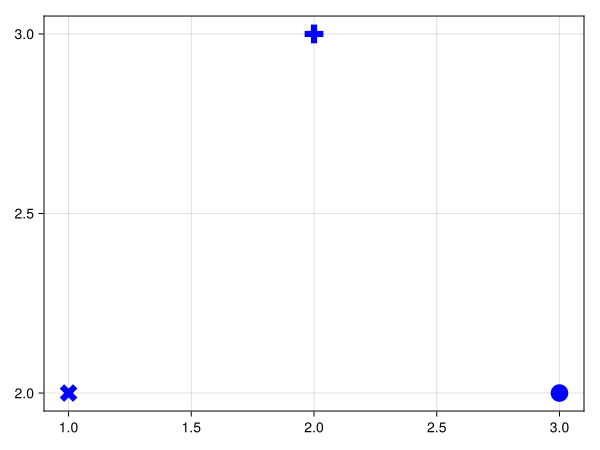

```julia
scatter(xs, ys;
        marker=[:x,:cross, :circle],
        markersize=25,
        color=:blue)
```

Figure 72.2: Different marker attributes

Marker attributes include

- `marker` a symbol, shape
- `markersize` size (radius pixels) of marker
- `marker_offset` offset coordinates
- `color` to adjust color

A single value will be repeated. A vector of values of a matching size will specify the attribute on a per point basis.

## 72.3 Curves

A visualized curve in calculus is comprised of line segments. The `lines` command of `Makie` will render a curve by connecting a series of points with straight-line segments. By taking a sufficient number of points the connect-the-dot figure can appear curved.

### 72.3.1 Plots of univariate functions

The basic plot of univariate calculus is the graph of a function $f$ over an interval $[a,b]$. This is implemented using a familiar strategy: produce a series of representative values between $a$ and $b$; produce the corresponding $f(x)$ values; plot these as points and connect the points with straight lines.

To create regular values between `a` and `b` typically the `range` function or the range operator (`a:h:b`) are employed. The related `LinRange` function is also an option.

For example:

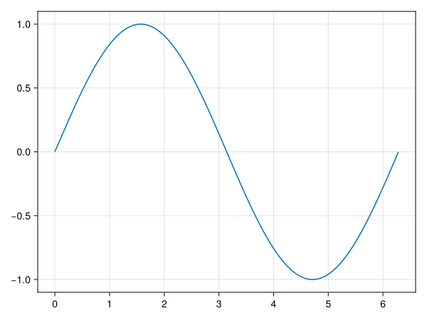

```julia
f(x) = sin(x)
a, b = 0, 2pi
xs = range(a, b, length=250)
lines(xs, f.(xs))
```

Figure 72.3: Use of `lines` to generate a curve

Makie has a recipe that allows the `y` position to be just the function—`lines(xs, f)` would have generated Figure 72.3 as well.

`Makie` also will read the interval notation of `IntervalSets` and select its own set of intermediate points, so this command would also render the same plot as that of Figure 72.3: `lines(a..b, f)`.

As with `scatter`, `lines` can also be drawn using a vector of points. (Though the advantage isn’t clear here, this will be useful when the points are generated in different manners.) In this case, this approach would involve a command like `lines(Point2.(xs, f.(xs)))`.

As with `scatter`, `lines` returns an object that produces a graphic when displayed.

When a `y` value is `NaN` or infinite, the connecting lines are not drawn:

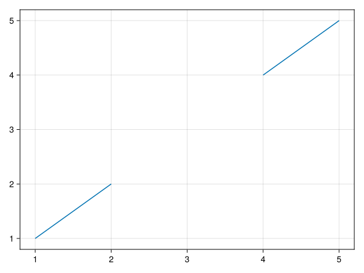

```julia
xs = 1:5
ys = [1,2,NaN, 4, 5]
lines(xs, ys)
```

Figure 72.4: An `NaN` value in the `y` vector has no connecting line segment

As with other plotting packages, this is useful to represent discontinuous functions, such as what occurs at a vertical asymptote or a step function.

#### Adding to a figure (`lines!`, `scatter!`, …)

To *add* or *modify* a figure can be done using a mutating version of a plotting primitive, such as `lines!` or `scatter!`. The names follow `Julia`’s convention of using an `!` to indicate that a function modifies an argument, in this case the underlying figure.

Here is one way to show two plots at once:

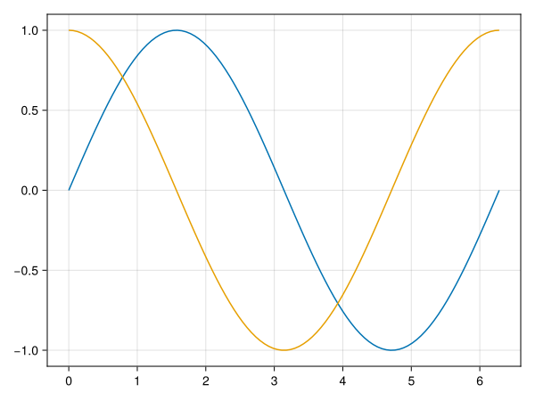

```julia
xs = range(0, 2pi, length=100)
lines(xs, sin)       # use function, not values from sin.(xs)
lines!(xs, cos)
current_figure()
```

Figure 72.5: Using `lines!` to add a layer

**NoteCurrent figure**

The `current_figure` call is needed to have the figure display, as the returned value of `lines!` is not a figure object. (Figure objects display when shown as the output of a cell.)

We will see soon how to modify the line attributes so that the curves can be distinguished.

Figure 72.6 shows the construction details to produce the graphic.

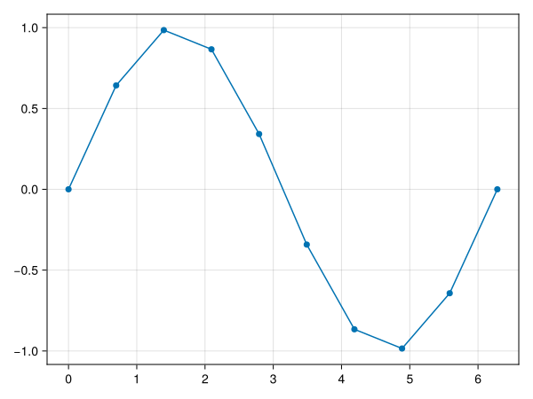

```julia
xs = range(0, 2pi, length=10)
lines(xs, sin)
scatter!(xs, sin;
         markersize=10)
current_figure()
```

Figure 72.6: Using `scatter!` to show the points used when creating a dot-to-dot plot

As an example, Figure 72.7 shows how to add the tangent line to a graph. The slope of the tangent line being computed by `ForwardDiff.derivative`.

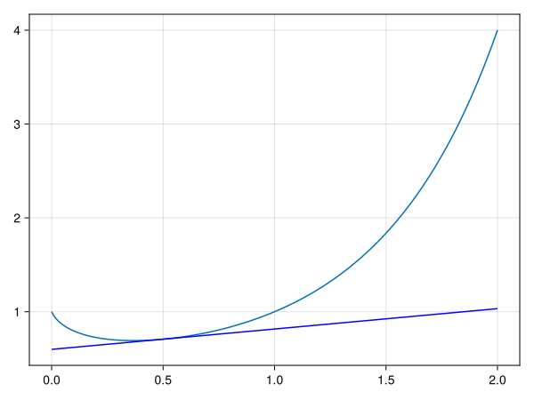

```julia
using ForwardDiff: derivative
f(x) = x^x
a, b= 0, 2
c = 0.5
xs = range(a, b, length=200)

tl(x) = f(c) + derivative(f, c) * (x-c)

lines(xs, f)
lines!(xs, tl, color=:blue)
current_figure()
```

Figure 72.7: Adding a tangent line to a curve at a point

This example[^1] shows how to plot a step function (`floor`) using `NaN`s to create line breaks. The marker colors set for `scatter!` use `:white` to match the background color.

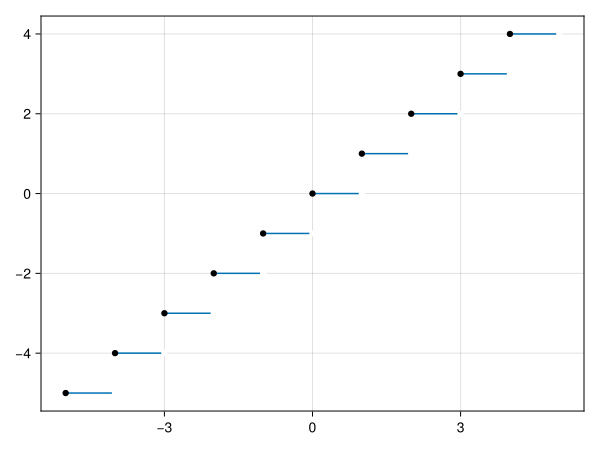

```julia
x = -5:5
δ = 5eps() # for rounding purposes; our interval is [i,i+1) ≈ [i, i+1-δ]
xx = Float64[]
for i ∈ x[1:end-1]
    append!(xx, (i, i+1 - δ, NaN))
end
yy = floor.(xx)

lines(xx, yy)
scatter!(xx, yy, color=repeat([:black, :white, :white], length(xx)÷3))

current_figure()
```

Figure 72.8: Using layers to plot a step function

### 72.3.2 Text (`annotations`)

Text can be placed at a point, as a marker is. To place text, the desired text and a position need to be specified along with any adjustments to the default attributes.

For example Figure 72.9 show an annotation and the use of `fontsize` to adjust the displayed text size.

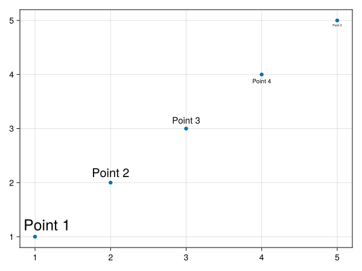

```julia
xs = 1:5
pts = Point2.(xs, xs)
scatter(pts)
annotation!(pts;
            text = "Point " .* string.(xs),
            fontsize = 30 .- 5*xs)

current_figure()
```

Figure 72.9: Using `annotation!` to add text within a graphic

Attributes for `text`, among many others, include:

- `align` Specify the text alignment through `(:pos, :pos)`, where `:pos` can be `:left`, `:center`, or `:right`.
- `fontsize` the font point size for the text
- `font` to indicate the desired font

Annotations with an arrow can be useful to highlight a feature of a graph. The code to produce Figure 72.10 is modified from the documentation of Makie; it utilizes some interval functions to draw an arrow with an arc.[^2]

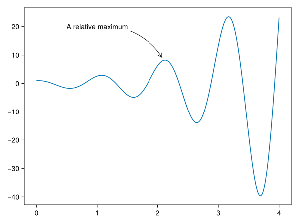

```julia
g(x) = cos(6x) * exp(x)
xs = 0:0.01:4

# this next line gets the Axis object from the FigureAxisPlot object
_, ax, _ = lines(xs, g;
                 axis = (; xgridvisible = false, ygridvisible = false))

annotation!(ax, 1, 20, 2.1, g(2.1), # annotate an Axis object
    text = "A relative maximum",
    path = Ann.Paths.Arc(0.3),
    style = Ann.Styles.LineArrow(),
    labelspace = :data
)

current_figure()
```

Figure 72.10: Use of `path` and `style` attributes of `annotation!` to draw an arrow

#### Line attributes

In a previous example, we added the argument `color=:blue` to the `lines!` call. This was to set an attribute for the line being drawn. Lines have other attributes that allow different ones to be distinguished, as above where colors indicate the different graphs.

Other attributes can be seen from the help page for `lines`, and include:

- `color` set with a symbol, as above, or a string
- `label` a label for the line to display in a legend
- `linestyle` available styles are set by a symbol, one of `:dash`, `:dot`, `:dashdot`, or `:dashdotdot`.
- `linewidth` width of line
- `transparency` the `alpha` value, a number between $0$ and $1$, smaller numbers for more transparent.

#### Simple legends

A simple legend displaying labels given to each curve can be produced by `axislegend`. For example:

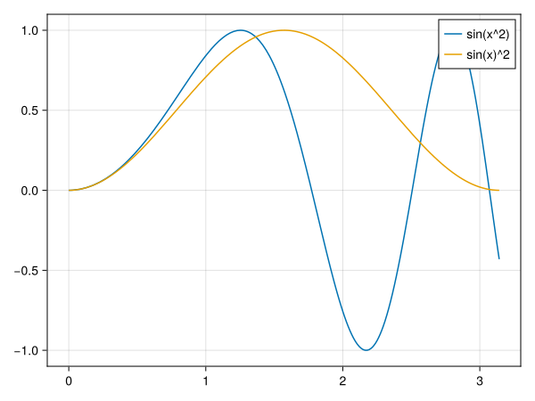

```julia
xs = 0..pi
lines(xs, x -> sin(x^2), label="sin(x^2)")
lines!(xs, x -> sin(x)^2, label = "sin(x)^2")
axislegend()

current_figure()
```

Later, we will see how to control the placement of a legend within a figure.

#### Titles, axis labels, axis ticks

The basic plots we have seen are of type `FigureAxisPlot`. The “axis” part controls attributes of the plot such as titles, labels, tick positions, etc. These values can be set in different manners. On construction we can pass values to a named argument `axis` using a named tuple.

For example:

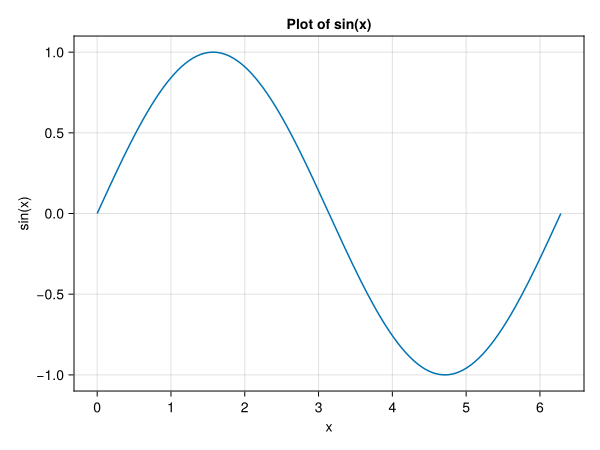

```julia
xs = 0..2pi
lines(xs, sin;
      axis=(title="Plot of sin(x)", xlabel="x", ylabel="sin(x)")
      )
```

Figure 72.11: Passing `title`, `xlabel`, and `ylabel` values to the underlying axis

To access the `axis` element of a plot **after** the plot is constructed, values can be assigned to the `axis` property of the `FigureAxisPlot` object. For example:

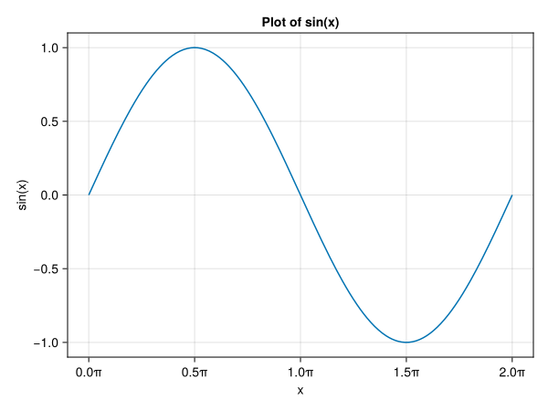

```julia
xs = 0..2pi
p = lines(xs, sin;
          axis=(title="Plot of sin(x)", xlabel="x", ylabel="sin(x)")
          )
p.axis.xticks = MultiplesTicks(5, pi, "π") # label 5 times using `pi`

current_figure()
```

Figure 72.12: One way to access the underlying axis after construction. (The more systematic way is to produce a `Figure` and construct an `Axis` object to modify.)

The ticks are most easily set as a collection of values. Above, the `MultiplesTicks` function was used to label with multiples of $\pi$.

Later we will discuss how `Makie` allows for subsequent modification of several parts of the plot (not just the ticks) including the data.

#### Figure size, $x$ and $y$ limits

As just mentioned, the basic plots we have seen are of type `FigureAxisPlot`. The “figure” part can be used to adjust the background color or the size. As with attributes for the axis, these too can be passed to a simple constructor:

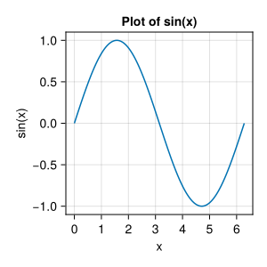

```julia
lines(xs, sin;
      axis=(title="Plot of sin(x)", xlabel="x", ylabel="sin(x)"),
      figure=(;size=(300, 300))
      )
```

Figure 72.13: Adjust `size` value for the enclosing `Figure` object

The `;` in the tuple passed to `figure` is one way to create a *named* tuple with a single element.

To set the limits of the graph there are shorthand functions `xlims!`, `ylims!`, and `zlims!`. This might prove useful if vertical asymptotes are encountered, as in the code to produce Figure 72.14.

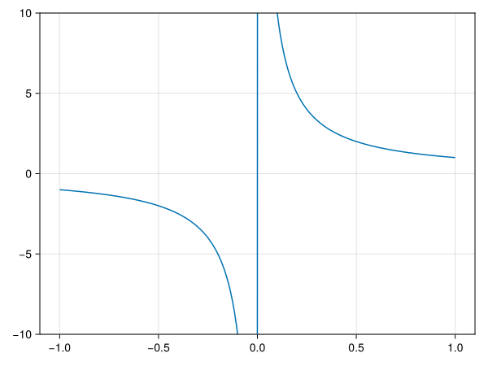

```julia
f(x) = 1/x
a,b = -1, 1
xs = range(-1, 1, length=200)
lines(xs, f)
ylims!(-10, 10)

current_figure()
```

Figure 72.14: Adjusting the range of possible `y` values with `ylims!`

Adjusting the `y` limits still leaves an artifact due to the vertical asymptote at $0$ having different values from the left and the right.

### 72.3.3 Plots of parametric functions

To construct a curve from a set of points, we have a similar pattern in both $2$ and $3$ dimensions:

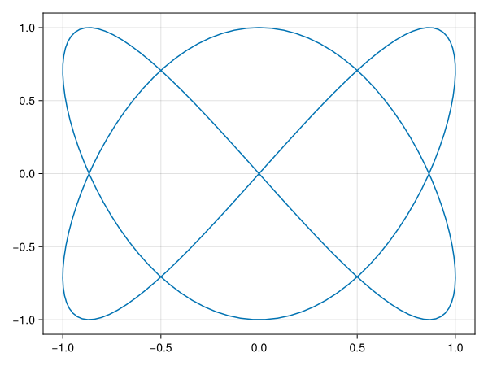

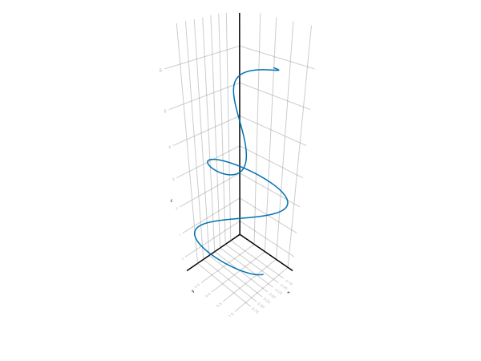

Figure 72.15: Two and three dimensional parametric plots

```julia
r(t) = [sin(2t), cos(3t)]
ts = range(0, 2pi, length=200)
pts = Point2.(r.(ts))  # or (Point2∘r).(ts)
lines(pts)
r(t) = [sin(2t), cos(3t), t]
ts = range(0, 2pi, length=200)
pts = Point3.(r.(ts))
lines(pts)
```

Alternatively, vectors of the $x$, $y$, and $z$ components can be produced and then plotted using the pattern `lines(xs, ys)` or `lines(xs, ys, zs)`. For example, using `unzip`, as above, we might have done the prior example with `lines(unzip(r.(ts))...)`.

#### Aspect ratio

A simple plot of a parametrically defined circle will show an ellipse, as the aspect ratio of the $x$ and $y$ axis is not $1$. To enforce this, we can pass a value of `aspect=1` to the underlying “Axis” object. Figure 72.16 provides an example.

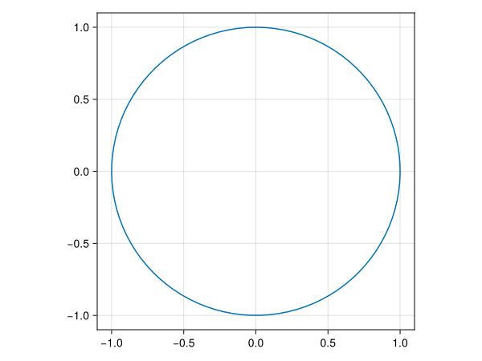

```julia
ts = range(0, 2pi, length=100)
lines(sin.(ts), cos.(ts);
      axis=(; aspect = 1))
```

Figure 72.16: Passing `aspect=1` to the axis make the `x` and `y`-axis scales equal

#### Tangent vectors (`arrows`)

A tangent vector along a curve can be drawn quite easily using the `arrows` function. There are different interfaces for `arrows`, but we show the one which uses a vector of positions and a vector of “vectors”. For the latter, we utilize the `derivative` function from `ForwardDiff`. In 3 dimensions the differences are minor, as seen in the code to produce Figure 72.17.

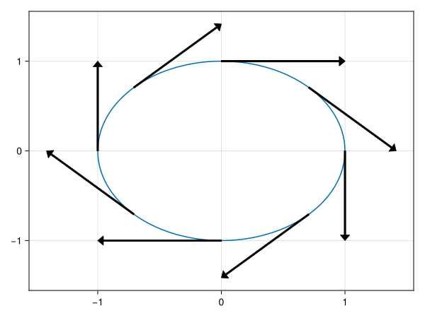

```julia
r(t) = [sin(t), cos(t)] # vector, not tuple
ts = range(0, 4pi, length=200)
lines(Point2.(r.(ts)))

nts = 0:pi/4:2pi
us = r.(nts)
dus = derivative.(r, nts)

arrows2d!(Point2.(us), Point2.(dus))

current_figure()
r(t) = [sin(t), cos(t), t] # vector, not tuple
ts = range(0, 4pi, length=200)
lines(Point3.(r.(ts)))

nts = 0:pi/2:(4pi-pi/2)
us = r.(nts)
dus = derivative.(r, nts)

arrows3d!(Point3.(us), Point3.(dus))

current_figure()
```

and

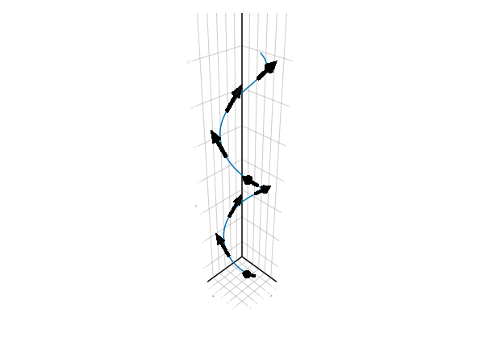

Figure 72.17: Plot of tangent lines in both two and three dimensions

#### Arrow attributes

Attributes for `arrows` include

- `arrowsize` to adjust the size
- `lengthscale` to scale the size
- `arrowcolor` to set the color
- `arrowhead` to adjust the head
- `arrowtail` to adjust the tail

## 72.4 Surfaces

Plots of surfaces in $3$ dimensions are useful to help understand the behavior of multivariate functions. There are a few common visualizations.

#### Surfaces defined through $z=f(x,y)$

The “`peaks`” function defined below has a few prominent peaks:

```julia
function peaks(x, y)
    p = 3*(1-x)^2*exp(-x^2 - (y+1)^2)
    p -= 10(x/5-x^3-y^5)*exp(-x^2-y^2)
    p -= 1/3*exp(-(x+1)^2-y^2)
    p
end
```

```
peaks (generic function with 1 method)
```

Figure 72.18 shows how `peaks` can be visualized over the region $[-5,5]\times[-5,5]$:

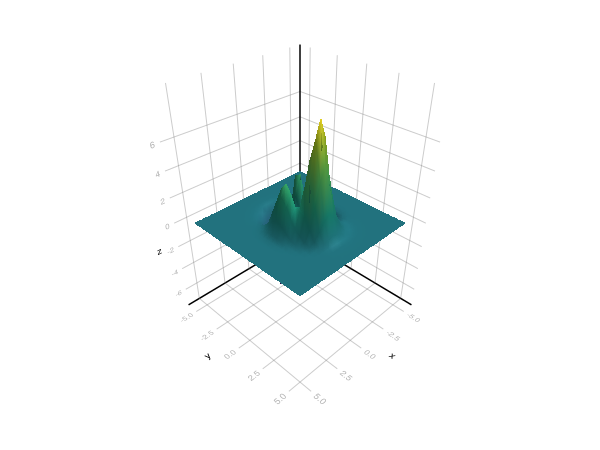

```julia
xs = ys = range(-5, 5, length=25)
surface(xs, ys, peaks)
```

Figure 72.18: Surface plot produced by `surface(xs, ys, f)`

The calling pattern `surface(xs, ys, f)` implies a rectangular grid over the $x$-$y$ plane defined by `xs` and `ys` with $z$ values given by $f(x,y)$.

Alternatively a “matrix” of $z$ values can be specified. For a function `f`, this is conveniently generated by the pattern `f.(xs, ys')`, the `'` being important to get a matrix of all $x$-$y$ pairs through `Julia`’s broadcasting syntax.

```julia
zs = peaks.(xs, ys')
surface(xs, ys, zs);
```

##### Example: surface graph construction

To see how a surface graph is constructed, the points $(x,y,f(x,y))$ are plotted over the grid and displayed.

In this examplpe, we downsample to illustrate.

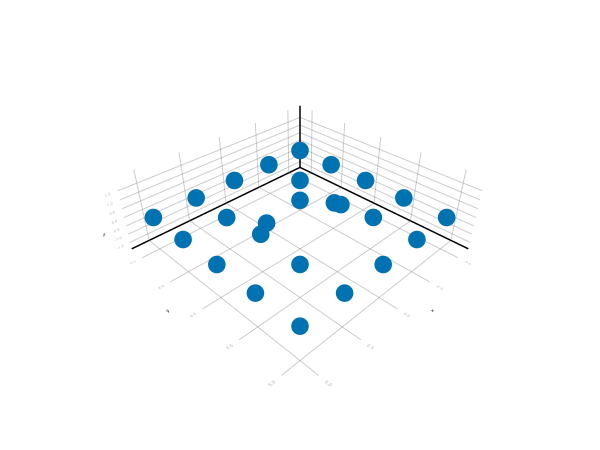

```julia
xs = ys = range(-5, 5, length=5)
pts = [Point3(x, y, peaks(x,y)) for x in xs for y in ys]
scatter(pts, markersize=25)
```

Figure 72.20: Points used in downsampled graphic

The points in Figure 72.20 are then connected. The `wireframe` function illustrates just the frame in Figure 72.21.

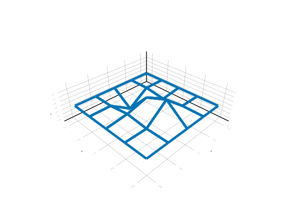

```julia
wireframe(xs, ys, peaks.(xs, ys'); linewidth=5)
```

Figure 72.21: Wireframe used in downsampled graphic

The `surface` call triangulates the frame and fills in the shading.

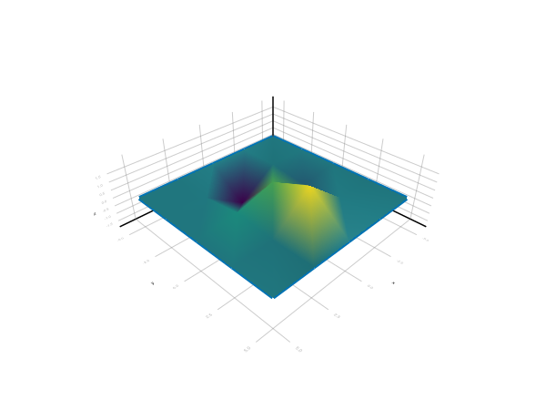

```julia
surface!(xs, ys, peaks.(xs, ys'))
current_figure()
```

Figure 72.22: The `surface` shading used in the downsampled graphic

#### Parametrically defined surfaces

A surface may be parametrically defined through a function $r(u,v) = (x(u,v), y(u,v), z(u,v))$. For example, the surface generated by $z=f(x,y)$ is of the form with $r(u,v) = (u,v,f(u,v))$.

The `surface` function and the `wireframe` function can be used to display such surfaces. In previous usages, the `x` and `y` values were vectors from which a 2-dimensional grid is formed. For parametric surfaces, a grid for the `x` and `y` values must be generated. This function will do so:

```julia
function parametric_grid(us, vs, r)
    n,m = length(us), length(vs)
    xs, ys, zs = zeros(n,m), zeros(n,m), zeros(n,m)
    for (i, uᵢ) in pairs(us)
        for (j, vⱼ) in pairs(vs)
            x,y,z = r(uᵢ, vⱼ)
            xs[i,j] = x
            ys[i,j] = y
            zs[i,j] = z
        end
    end
    (xs, ys, zs)
end
```

```
parametric_grid (generic function with 1 method)
```

With the data suitably massaged, we can directly plot either a `surface` or `wireframe` plot.

As an aside, The above can be done more campactly with nested list comprehensions:

```
xs, ys, zs = [[pt[i] for pt in r.(us, vs')] for i in 1:3]
```

Or using the `unzip` function directly after broadcasting:

```
xs, ys, zs = unzip(r.(us, vs'))
```

For example, a sphere can be parameterized by $r(u,v) = (\sin(u)\cos(v), \sin(u)\sin(v), \cos(u))$ and visualized through these commands to produce Figure 72.23.

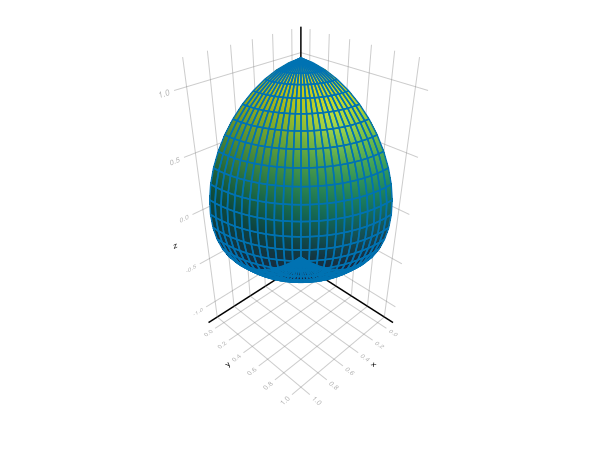

```julia
r(u,v) = [sin(u)*cos(v), sin(u)*sin(v), cos(u)]

us = range(0, pi, length=25)
vs = range(0, pi/2, length=25)
xs, ys, zs = parametric_grid(us, vs, r)

surface(xs, ys, zs)
wireframe!(xs, ys, zs)
current_figure()
```

Figure 72.23: Part of sphere plotted using a parametric description of the data

A surface of revolution for $g(u)$ revolved about the $z$ axis can be visualized through the commands to produce Figure 72.24.

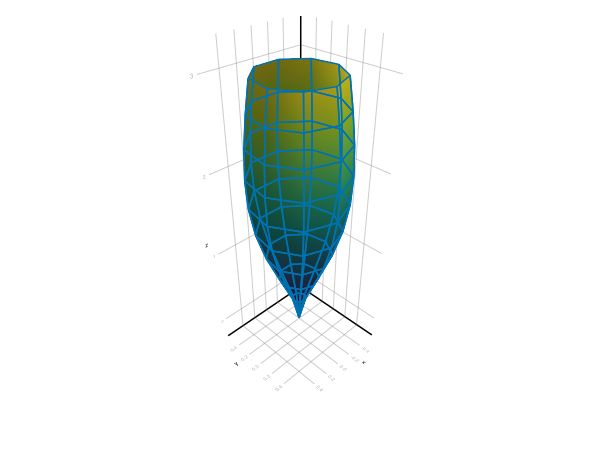

```julia
g(u) = u^2 * exp(-u)
r(u,v) = (g(u)*sin(v), g(u)*cos(v), u)

us = range(0, 3, length=10)
vs = range(0, 2pi, length=10)
xs, ys, zs = parametric_grid(us, vs, r)

surface(xs, ys, zs)
wireframe!(xs, ys, zs)
current_figure()
```

Figure 72.24: Surface of revolution formed by revolving `g` around the `z` axis.

A torus with big radius $2$ and inner radius $1/2$ is visualized in Figure 72.25.

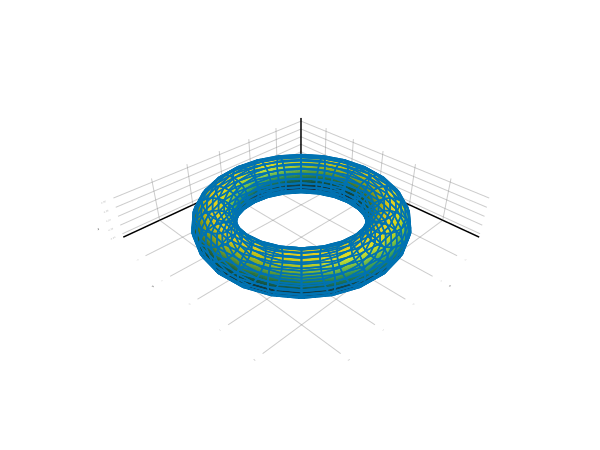

```julia
r1, r2 = 2, 1/2
r(u,v) = ((r1 + r2*cos(v))*cos(u), (r1 + r2*cos(v))*sin(u), r2*sin(v))

us = vs = range(0, 2pi, length=25)
xs, ys, zs = parametric_grid(us, vs, r)

surface(xs, ys, zs)
wireframe!(xs, ys, zs)
current_figure()
```

Figure 72.25: Surface of torus plotted as a parametrically defined surface

A Möbius strip is produced in Figure 72.26.

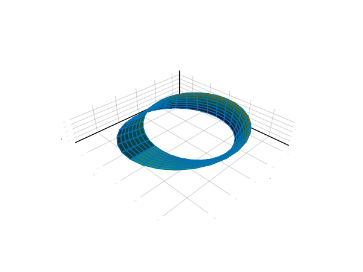

```julia
r(w, θ) = ((1+w*cos(θ/2))*cos(θ), (1+w*cos(θ/2))*sin(θ), w*sin(θ/2))

ws = range(-1/4, 1/4, length=8)
thetas = range(0, 2pi, length=30)
xs, ys, zs = parametric_grid(ws, thetas, r)

surface(xs, ys, zs)
wireframe!(xs, ys, zs)
current_figure()
```

Figure 72.26: A Möbius strip can be parameterized and displayed